```python
# Dependencies
import pandas as pd
import numpy as np
from statistics import pstdev
import matplotlib.pyplot as plt
import seaborn as sns


import glob
import random
import base64

from PIL import Image
from io import BytesIO
from IPython.display import HTML

%matplotlib inline
```

# Introduction

**Cihan Acilov | Audrya Kerenhappukh | Anuruddha Punam Kristhombuge** **11/8/2021**

This notebook presents the results of the assignment that is carried out for the class Math, Statistics and R (MSR) of the the minor program 3DM that is provided by Hogeschool van Arnhem & Nijmegen.

The notebook presents the results of the assignment: rather than showing the code, the output is presented.

The functions needed to prepare the data and to make the visualizations are saved into the **python file msr_functions.py** which is in the same directory as this notebook. The python file will be imported later in this notebook.

## The assignment

The **first** task is to re-create the table below in Python. Create Histogram and Score columns that contains inline graph in rows.

[figure not shown]

The **second** task is to create following calculated columns:Cumulative, Frequency,Cumulative(%), Frequency(%).

Based on this new columns the visuals below will be calculated:

[figure not shown]

The **third** task is to create following calculated columns:Mean, Std_Dev, Skewness,Kurtosis and Mean of Mean, Std_Dev, Skewness and Kurtosis.

Based on this new columns the visuals below will be calculated:

[figure not shown]

# The Results

Here below the end results in png format:

**Table with inline graphs**

[figure not shown]

**Cumulative and Frequency of Distribution of Grades**

[figure not shown]

*Overall Distribution of Marks* is showing the distribution of grades in numbers. The line value is showing the cumulative count of grades, which is equel to 66 (11 students, 6 course = 66 grades).

*Overall Distribution of Marks%* is showing the distribution of grades in percentile. The line value is showing the cumulative count of grades in percentile.

**Mean, Std_Dev, Skewness and Kurtosis of Grade by Students**

[figure not shown]

**Mean, Std_Dev, Skewness and Kurtosis of Grade by Courses**

[figure not shown]

1. *Mean of grade by course*: the (orange) line value shows the mean of grades by courses. Black line value shows the mean of mean. The mean of all grades in Course 2 and Course 6 are higher than the average of mean of all courses.
1. *Std_Dev of grade by course*: the (orange) line value shows the standard deviation of grades by courses. The black line is showing the average standard deviation by course. Course 2 and Course 6 have lower standard deviation.
1. *Skewness of grade by course*: the (orange) line value shows the skewness of grades by courses. The black line is showing the average skewness of grades by course. Course 4 has the highest skewness and the course 5 has the lowest.
1. *Kurtosis of grade by course*: the (orange) line value shows the kurtosis of student grades. The black line is showing the average kurtosis of grades by courses. Course 4 has the highest kurtosis and the course 3 has the lowest.

# Importing the assignment dataset

Assignment dataset contains the grades of 11 students for 6 different courses.

```python
maindf = pd.read_excel('StudentsGrade.xlsx')
maindf
```

|  | Students | Course1 | Course2 | Course3 | Course4 | Course5 | Course6 |
| --- | --- | --- | --- | --- | --- | --- | --- |
| 0 | a | 3 | 9 | 9 | 3 | 8 | 9 |
| 1 | b | 8 | 8 | 7 | 4 | 8 | 8 |
| 2 | c | 9 | 10 | 9 | 9 | 6 | 10 |
| 3 | d | 4 | 7 | 4 | 2 | 7 | 9 |
| 4 | e | 7 | 9 | 8 | 4 | 7 | 9 |
| 5 | f | 10 | 7 | 4 | 3 | 4 | 8 |
| 6 | g | 5 | 9 | 8 | 5 | 7 | 10 |
| 7 | h | 6 | 9 | 5 | 4 | 6 | 10 |
| 8 | i | 4 | 8 | 6 | 4 | 4 | 10 |
| 9 | j | 7 | 7 | 5 | 1 | 4 | 9 |
| 10 | k | 10 | 7 | 9 | 7 | 6 | 8 |

So the dataset **df** is going to be used as the main dataset from which two different dataset will be created:

1. dfstudents
2. dfcourses

In the datasets **dfstudent** and **dfcourses** the columns below will be created:

1. Mean
2. Std_Dev
3. Skewness
4. Kurtosis
5. Average of Mean
6. Average of Std_Dev
7. Average of Skewness
8. Average of Kurtosis

Additionally in **dfstudent** the columns below will be created to calculate the count of grades (frequency & cumulative)

1. Cumulative
2. Frequency
3. Cumulative%
4. Frequency%

# MSR - Functions

```python
import msr_functions
```

```
Hi, welcome to MSR-Functions. Created on 12 November 2021.

The library contains the functions below:
1. dstudent_creator(df)
2. dscourse_creator(df)
3. visual_dist_marks(df)
4. visual_dist_marks_percentile(df)
5. visual_grade_student(column, df)
6. visual_grade_course(column, df)
7. visual_sparkline_bar(df)
```

The directory where this notebook (MSR_Final.ipynb) is located, contains the **msr_functions.py**. This py file contains all the functions needed to be able carry out the MSR Assignment. Importing the functions from the py file, helps keeping this notebook cleaner, so that only the results of the assignment can be described and explained in the notebook, rather the explaining the code and the functions.

## MSR Functions: dfstudent_creator()

**dfstudent_creator(df)** excepts a pandas dataframe (df) and returns a new dataframe with following calculated columns:

1. Cumulative,Frequency, Cumulative% and Frequency%
2. Sum, Mean, Std_Dev, Skewness and Kurtosis
3. Mean of Mean, Std_Dev, Skewness and Kurtosis

```python
dfstudent = msr_functions.dfstudent_creator(maindf)
```

```
DataFrame with new coumns is created!
```

```python
dfstudent
```

|  | Students | Course1 | Course2 | Course3 | Course4 | Course5 | Course6 | grade | Cumulative | Frequency | ... | Frequency% | Sum | Mean | Std_Dev | Skewness | Kurtosis | Average_Mean | Average_Std_Dev | Average_Skewness | Average_Kurtosis |
| --- | --- | --- | --- | --- | --- | --- | --- | --- | --- | --- | --- | --- | --- | --- | --- | --- | --- | --- | --- | --- | --- |
| 0 | a | 3 | 9 | 9 | 3 | 8 | 9 | 0 | 0 | 0 | ... | 0.0 | 41 | 6.83 | 2.73 | -0.90 | -1.90 | 6.82 | 2.03 | -0.41 | 0.11 |
| 1 | b | 8 | 8 | 7 | 4 | 8 | 8 | 1 | 1 | 1 | ... | 1.5 | 43 | 7.17 | 1.46 | -2.15 | 4.64 | 6.82 | 2.03 | -0.41 | 0.11 |
| 2 | c | 9 | 10 | 9 | 9 | 6 | 10 | 2 | 2 | 1 | ... | 1.5 | 53 | 8.83 | 1.34 | -1.84 | 3.91 | 6.82 | 2.03 | -0.41 | 0.11 |
| 3 | d | 4 | 7 | 4 | 2 | 7 | 9 | 3 | 5 | 3 | ... | 4.5 | 33 | 5.50 | 2.36 | 0.00 | -1.25 | 6.82 | 2.03 | -0.41 | 0.11 |
| 4 | e | 7 | 9 | 8 | 4 | 7 | 9 | 4 | 16 | 11 | ... | 16.7 | 44 | 7.33 | 1.70 | -1.28 | 1.85 | 6.82 | 2.03 | -0.41 | 0.11 |
| 5 | f | 10 | 7 | 4 | 3 | 4 | 8 | 5 | 20 | 4 | ... | 6.1 | 36 | 6.00 | 2.52 | 0.43 | -1.57 | 6.82 | 2.03 | -0.41 | 0.11 |
| 6 | g | 5 | 9 | 8 | 5 | 7 | 10 | 6 | 25 | 5 | ... | 7.6 | 44 | 7.33 | 1.89 | -0.05 | -1.72 | 6.82 | 2.03 | -0.41 | 0.11 |
| 7 | h | 6 | 9 | 5 | 4 | 6 | 10 | 7 | 36 | 11 | ... | 16.7 | 40 | 6.67 | 2.13 | 0.60 | -1.29 | 6.82 | 2.03 | -0.41 | 0.11 |
| 8 | i | 4 | 8 | 6 | 4 | 4 | 10 | 8 | 46 | 10 | ... | 15.2 | 36 | 6.00 | 2.31 | 0.89 | -0.78 | 6.82 | 2.03 | -0.41 | 0.11 |
| 9 | j | 7 | 7 | 5 | 1 | 4 | 9 | 9 | 59 | 13 | ... | 19.7 | 33 | 5.50 | 2.57 | -0.61 | 0.20 | 6.82 | 2.03 | -0.41 | 0.11 |
| 10 | k | 10 | 7 | 9 | 7 | 6 | 8 | 10 | 66 | 7 | ... | 10.6 | 47 | 7.83 | 1.34 | 0.42 | -0.86 | 6.82 | 2.03 | -0.41 | 0.11 |

11 rows × 21 columns

## MSR Functions: dfcourse_creator()

**dfcourse_creator(df)** excepts a pandas dataframe (df) and returns a new dataframe with following calculated columns:

1. Sum, Mean, Std_Dev, Skewness and Kurtosis
2. Mean of Mean, Std_Dev, Skewness and Kurtosis

```python
dfcourse = msr_functions.dfcourse_creator(maindf)
```

```
DataFrame with new coumns is created!
```

```python
dfcourse
```

|  | Course | a | b | c | d | e | f | g | h | i | ... | k | Sum | Mean | Std_Dev | Skewness | Kurtosis | Average_Mean | Average_Std_Dev | Average_Skewness | Average_Kurtosis |
| --- | --- | --- | --- | --- | --- | --- | --- | --- | --- | --- | --- | --- | --- | --- | --- | --- | --- | --- | --- | --- | --- |
| 0 | Course1 | 3 | 8 | 9 | 4 | 7 | 10 | 5 | 6 | 4 | ... | 10 | 73 | 6.64 | 2.35 | 0.02 | -1.32 | 6.82 | 1.61 | 0.06 | -0.97 |
| 1 | Course2 | 9 | 8 | 10 | 7 | 9 | 7 | 9 | 9 | 8 | ... | 7 | 90 | 8.18 | 1.03 | 0.15 | -1.39 | 6.82 | 1.61 | 0.06 | -0.97 |
| 2 | Course3 | 9 | 7 | 9 | 4 | 8 | 4 | 8 | 5 | 6 | ... | 9 | 74 | 6.73 | 1.91 | -0.18 | -1.74 | 6.82 | 1.61 | 0.06 | -0.97 |
| 3 | Course4 | 3 | 4 | 9 | 2 | 4 | 3 | 5 | 4 | 4 | ... | 7 | 46 | 4.18 | 2.12 | 0.98 | 1.28 | 6.82 | 1.61 | 0.06 | -0.97 |
| 4 | Course5 | 8 | 8 | 6 | 7 | 7 | 4 | 7 | 6 | 4 | ... | 6 | 67 | 6.09 | 1.44 | -0.40 | -1.16 | 6.82 | 1.61 | 0.06 | -0.97 |
| 5 | Course6 | 9 | 8 | 10 | 9 | 9 | 8 | 10 | 10 | 10 | ... | 8 | 100 | 9.09 | 0.79 | -0.19 | -1.49 | 6.82 | 1.61 | 0.06 | -0.97 |

6 rows × 21 columns

# Visualization

## MSR-Function: visual_dist_marks(df) & visual_dist_marks_percentile(df)

The functions *visual_dist_marks(df) & visual_dist_marks_percentile(df) excepts the **studentdf** and creates visuals for count in cumulative and frequency

```python
dfstudent
```

|  | Students | Course1 | Course2 | Course3 | Course4 | Course5 | Course6 | grade | Cumulative | Frequency | ... | Frequency% | Sum | Mean | Std_Dev | Skewness | Kurtosis | Average_Mean | Average_Std_Dev | Average_Skewness | Average_Kurtosis |
| --- | --- | --- | --- | --- | --- | --- | --- | --- | --- | --- | --- | --- | --- | --- | --- | --- | --- | --- | --- | --- | --- |
| 0 | a | 3 | 9 | 9 | 3 | 8 | 9 | 0 | 0 | 0 | ... | 0.0 | 41 | 6.83 | 2.73 | -0.90 | -1.90 | 6.82 | 2.03 | -0.41 | 0.11 |
| 1 | b | 8 | 8 | 7 | 4 | 8 | 8 | 1 | 1 | 1 | ... | 1.5 | 43 | 7.17 | 1.46 | -2.15 | 4.64 | 6.82 | 2.03 | -0.41 | 0.11 |
| 2 | c | 9 | 10 | 9 | 9 | 6 | 10 | 2 | 2 | 1 | ... | 1.5 | 53 | 8.83 | 1.34 | -1.84 | 3.91 | 6.82 | 2.03 | -0.41 | 0.11 |
| 3 | d | 4 | 7 | 4 | 2 | 7 | 9 | 3 | 5 | 3 | ... | 4.5 | 33 | 5.50 | 2.36 | 0.00 | -1.25 | 6.82 | 2.03 | -0.41 | 0.11 |
| 4 | e | 7 | 9 | 8 | 4 | 7 | 9 | 4 | 16 | 11 | ... | 16.7 | 44 | 7.33 | 1.70 | -1.28 | 1.85 | 6.82 | 2.03 | -0.41 | 0.11 |
| 5 | f | 10 | 7 | 4 | 3 | 4 | 8 | 5 | 20 | 4 | ... | 6.1 | 36 | 6.00 | 2.52 | 0.43 | -1.57 | 6.82 | 2.03 | -0.41 | 0.11 |
| 6 | g | 5 | 9 | 8 | 5 | 7 | 10 | 6 | 25 | 5 | ... | 7.6 | 44 | 7.33 | 1.89 | -0.05 | -1.72 | 6.82 | 2.03 | -0.41 | 0.11 |
| 7 | h | 6 | 9 | 5 | 4 | 6 | 10 | 7 | 36 | 11 | ... | 16.7 | 40 | 6.67 | 2.13 | 0.60 | -1.29 | 6.82 | 2.03 | -0.41 | 0.11 |
| 8 | i | 4 | 8 | 6 | 4 | 4 | 10 | 8 | 46 | 10 | ... | 15.2 | 36 | 6.00 | 2.31 | 0.89 | -0.78 | 6.82 | 2.03 | -0.41 | 0.11 |
| 9 | j | 7 | 7 | 5 | 1 | 4 | 9 | 9 | 59 | 13 | ... | 19.7 | 33 | 5.50 | 2.57 | -0.61 | 0.20 | 6.82 | 2.03 | -0.41 | 0.11 |
| 10 | k | 10 | 7 | 9 | 7 | 6 | 8 | 10 | 66 | 7 | ... | 10.6 | 47 | 7.83 | 1.34 | 0.42 | -0.86 | 6.82 | 2.03 | -0.41 | 0.11 |

11 rows × 21 columns

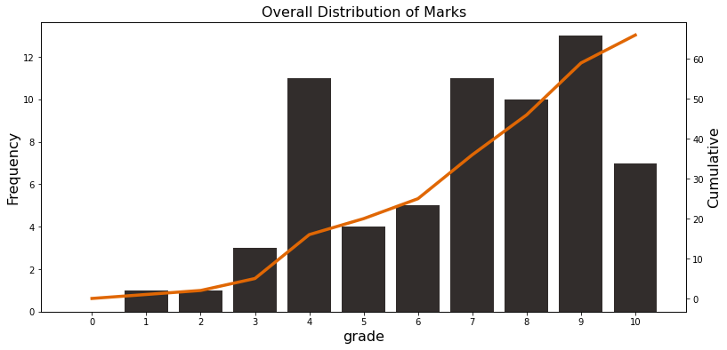

```python
overall_distribution_of_marks = msr_functions.visual_dist_marks(dfstudent)
overall_distribution_of_marks
```

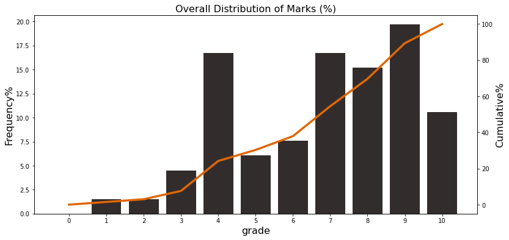

```python
cum_frq_per = msr_functions.visual_dist_marks_percentile(dfstudent)
cum_frq_per
```

## MSR-Function: visual_grade_student() & visual_grade_course()

The functions *visual_grade_student(column, df) & visual_grade_course(column, df) excepts a **dataframe** and **column name** and creates visuals comparing the average of given column name by student or course.

**Example**

visual_grade_student('Mean', dfstudent) will return a line-plot showing mean by students compared to average mean by student

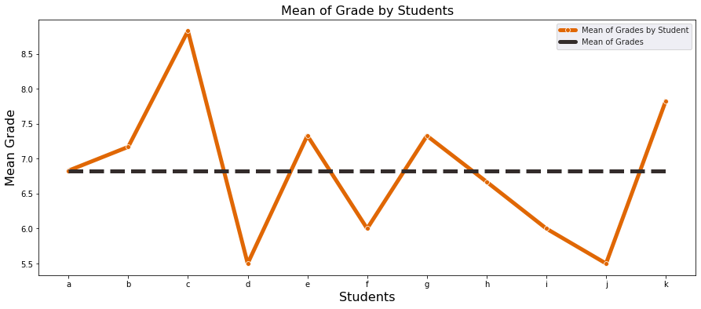

```python
column = 'Mean'
df = dfstudent
mean_grade_by_student = msr_functions.visual_grade_student(column,df)
```

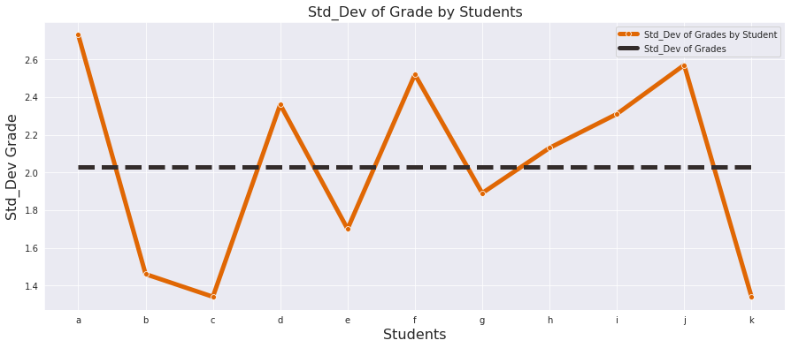

```python
column = 'Std_Dev'
df = dfstudent
std_dev_grade_by_student = msr_functions.visual_grade_student(column,df)
```

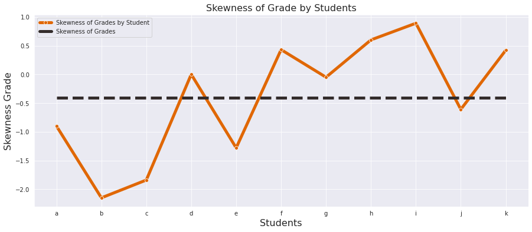

```python
column = 'Skewness'
df = dfstudent
skew_grade_by_student = msr_functions.visual_grade_student(column,df)
```

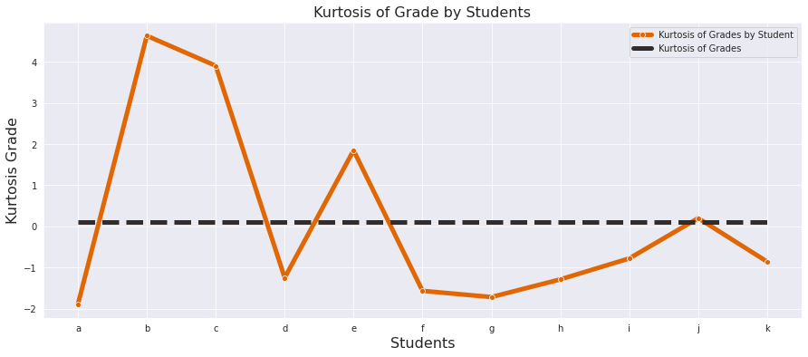

```python
column = 'Kurtosis'
df = dfstudent
kurtosis_grade_by_student = msr_functions.visual_grade_student(column,df)
```

```python
dfcourse
```

|  | Course | a | b | c | d | e | f | g | h | i | ... | k | Sum | Mean | Std_Dev | Skewness | Kurtosis | Average_Mean | Average_Std_Dev | Average_Skewness | Average_Kurtosis |
| --- | --- | --- | --- | --- | --- | --- | --- | --- | --- | --- | --- | --- | --- | --- | --- | --- | --- | --- | --- | --- | --- |
| 0 | Course1 | 3 | 8 | 9 | 4 | 7 | 10 | 5 | 6 | 4 | ... | 10 | 73 | 6.64 | 2.35 | 0.02 | -1.32 | 6.82 | 1.61 | 0.06 | -0.97 |
| 1 | Course2 | 9 | 8 | 10 | 7 | 9 | 7 | 9 | 9 | 8 | ... | 7 | 90 | 8.18 | 1.03 | 0.15 | -1.39 | 6.82 | 1.61 | 0.06 | -0.97 |
| 2 | Course3 | 9 | 7 | 9 | 4 | 8 | 4 | 8 | 5 | 6 | ... | 9 | 74 | 6.73 | 1.91 | -0.18 | -1.74 | 6.82 | 1.61 | 0.06 | -0.97 |
| 3 | Course4 | 3 | 4 | 9 | 2 | 4 | 3 | 5 | 4 | 4 | ... | 7 | 46 | 4.18 | 2.12 | 0.98 | 1.28 | 6.82 | 1.61 | 0.06 | -0.97 |
| 4 | Course5 | 8 | 8 | 6 | 7 | 7 | 4 | 7 | 6 | 4 | ... | 6 | 67 | 6.09 | 1.44 | -0.40 | -1.16 | 6.82 | 1.61 | 0.06 | -0.97 |
| 5 | Course6 | 9 | 8 | 10 | 9 | 9 | 8 | 10 | 10 | 10 | ... | 8 | 100 | 9.09 | 0.79 | -0.19 | -1.49 | 6.82 | 1.61 | 0.06 | -0.97 |

6 rows × 21 columns

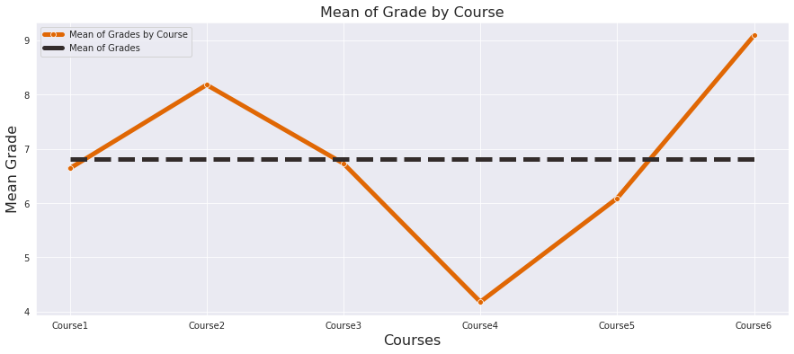

```python
column = 'Mean'
df = dfcourse
kurtosis_grade_by_student = msr_functions.visual_grade_course(column,df)
```

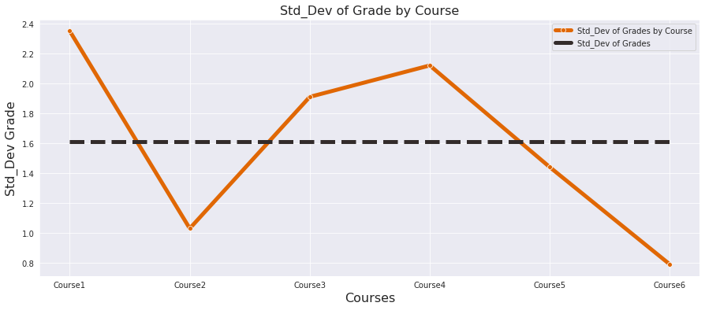

```python
column = 'Std_Dev'
df = dfcourse
kurtosis_grade_by_student = msr_functions.visual_grade_course(column,df)
```

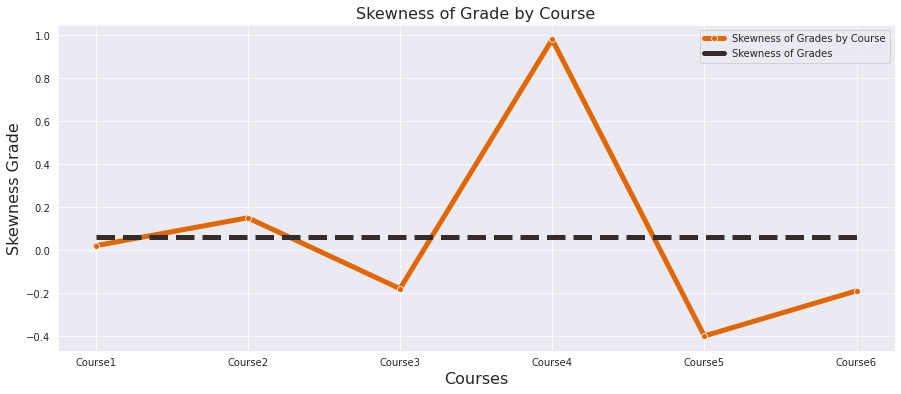

```python
column = 'Skewness'
df = dfcourse
kurtosis_grade_by_student = msr_functions.visual_grade_course(column,df)
```

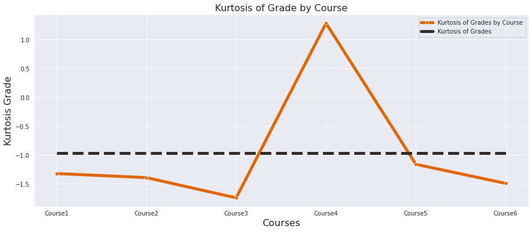

```python
column = 'Kurtosis'
df = dfcourse
kurtosis_grade_by_student = msr_functions.visual_grade_course(column,df)
```

```python
sparklineBarTable = msr_functions.visual_sparkline_bar(maindf)
```

## MSR-Function: visual_sparkline_bar(maindf)

The functions **visual_sparkline_bar(maindf)** excepts a **dataframe** and creates a table with inline sparklines and bar graphs in the rows.

```python
sparklineBarTable = msr_functions.visual_sparkline_bar(maindf)
sparklineBarTable
```

| Students | Course1 | Course2 | Course3 | Course4 | Course5 | Course6 | Histogram | Scores |
| --- | --- | --- | --- | --- | --- | --- | --- | --- |
| a | 3 | 9 | 9 | 3 | 8 | 9 |  |  |
| b | 8 | 8 | 7 | 4 | 8 | 8 |  |  |
| c | 9 | 10 | 9 | 9 | 6 | 10 |  |  |
| d | 4 | 7 | 4 | 2 | 7 | 9 |  |  |
| e | 7 | 9 | 8 | 4 | 7 | 9 |  |  |
| f | 10 | 7 | 4 | 3 | 4 | 8 |  |  |
| g | 5 | 9 | 8 | 5 | 7 | 10 |  |  |
| h | 6 | 9 | 5 | 4 | 6 | 10 |  |  |
| i | 4 | 8 | 6 | 4 | 4 | 10 |  |  |
| j | 7 | 7 | 5 | 1 | 4 | 9 |  |  |
| k | 10 | 7 | 9 | 7 | 6 | 8 |  |  |
| Histogram |  |  |  |  |  |  |  |  |
| Scores |  |  |  |  |  |  |  |  |

# Appendix

Here below is the code used in msr_functions.py

```python
import pandas as pd
import numpy as np
from statistics import pstdev
import matplotlib.pyplot as plt
import seaborn as sns


import glob
import random
import base64

from PIL import Image
from io import BytesIO
from IPython.display import HTML


print("Hi, welcome to MSR-Functions. Created on 12 November 2021.\n")

print("The library contains the functions below: ")
print("1. dstudent_creator(df)")
print("2. dscourse_creator(df)")
print("3. visual_dist_marks(df)")
print("4. visual_dist_marks_percentile(df)")
print("5. visual_grade_student(column, df)")
print("6. visual_grade_course(column, df)")
print("7. visual_sparkline_bar(df)")


# function to create student df with calculated columns (mean, stddev, freqeuncy etc)
# It accepts df that has std id and 6 courses as columns
def dfstudent_creator(df):

    dfstudent = df.copy()
    # #############CUMULATIVE FREQUENCY#######################################
    # Creating a list of grades
    grades = [0, 1, 2, 3, 4, 5, 6, 7, 8, 9, 10]
    dfstudent["grade"] = grades

    # List for CUMULATIVE count
    clist = []
    for i in dfstudent["grade"]:
        x = dfstudent[
            dfstudent[
                ["Course1", "Course2", "Course3", "Course4", "Course5", "Course6"]
            ]
            <= i
        ].count()
        c = 0
        for j in x:
            c = c + j
        clist.append(c)

    # List for FREQUENCY count
    flist = []
    for i in dfstudent["grade"]:
        x = dfstudent[
            dfstudent[
                ["Course1", "Course2", "Course3", "Course4", "Course5", "Course6"]
            ]
            == i
        ].count()
        c = 0
        for j in x:
            c = c + j
        flist.append(c)

    # Cumulative % list (<=)
    c_perc_list = []
    count = (
        dfstudent[["Course1", "Course2", "Course3", "Course4", "Course5", "Course6"]]
        .count()
        .sum()
        * 100
    )

    for i in dfstudent["grade"]:
        x = (
            dfstudent[
                dfstudent[
                    ["Course1", "Course2", "Course3", "Course4", "Course5", "Course6"]
                ]
                <= i
            ]
            .count()
            .sum()
        )
        y = round((x / count) * 10000, 1)
        c_perc_list.append(y)

    # Frequency % list (==)
    f_perc_list = []
    count = (
        dfstudent[["Course1", "Course2", "Course3", "Course4", "Course5", "Course6"]]
        .count()
        .sum()
        * 100
    )

    for i in dfstudent["grade"]:
        x = (
            dfstudent[
                dfstudent[
                    ["Course1", "Course2", "Course3", "Course4", "Course5", "Course6"]
                ]
                == i
            ]
            .count()
            .sum()
        )
        y = round((x / count) * 10000, 1)
        f_perc_list.append(y)

    # ############################ SUM,MEAN,STD,SKEW,KURTOSIS####################

    # Sum of all grades of each Student
    sumS_list = []
    for s, i, j, k, x, y, z in df.itertuples(index=False):

        sumS_list.append(sum([i, j, k, x, y, z]))

    # Mean of all grades of each Student
    meanS_list = round(df.mean(axis=1), 2)

    # Std_Dev of all grades of each Student
    stdS_list = []
    for s, i, j, k, x, y, z in df.itertuples(index=False):
        # Calculating STD_Dev for Population
        stdS_list.append(round(pstdev([i, j, k, x, y, z]), 2))

    # Skewness of all grades of each Student
    skewS_list = round(df.skew(axis=1), 2)

    # Kurtosis of all grades of each Student
    kurtS_list = round(df.kurtosis(axis=1), 2)

    # ########################## ADDING THE LISTS INTO DFSTUDENT ######################

    # Cumulative & Frequency
    dfstudent["Cumulative"] = clist
    dfstudent["Frequency"] = flist
    dfstudent["Cumulative%"] = c_perc_list
    dfstudent["Frequency%"] = f_perc_list

    # Sum, Mean, Std_Dev, Skewness and Kurtosis
    dfstudent["Sum"] = sumS_list
    dfstudent["Mean"] = meanS_list
    dfstudent["Std_Dev"] = stdS_list
    dfstudent["Skewness"] = skewS_list
    dfstudent["Kurtosis"] = kurtS_list
    dfstudent["Average_Mean"] = round(dfstudent["Mean"].mean(), 2)
    dfstudent["Average_Std_Dev"] = round(dfstudent["Std_Dev"].mean(), 2)
    dfstudent["Average_Skewness"] = round(dfstudent["Skewness"].mean(), 2)
    dfstudent["Average_Kurtosis"] = round(dfstudent["Kurtosis"].mean(), 2)

    print("DataFrame with new coumns is created!")

    return dfstudent


# Function below transposes the table and carry our the same functions as above for Courses ISO students
def dfcourse_creator(df):
    dfT = df
    dfT = dfT.set_index("Students")
    dfT = dfT.T
    column_names = dfT.columns
    dfT

    dfcourses = pd.DataFrame()

    lisst = []
    for i in dfT.index:
        lisst.append(i)

    dfcourses["Course"] = lisst

    lisst = []
    for x in column_names:
        item = dfT[x].values
        lisst.append(item)
        dfcourses[x] = item

        # Sum of all grades of each Course
    sumC_list = dfcourses.sum(axis=1)

    # Mean of all grades of each Course
    meanC_list = round(dfcourses.mean(axis=1), 2)

    # Std_Dev of all grades of each Course
    stdC_list = []
    for s, a, b, c, d, e, f, g, h, i, j, k in dfcourses.itertuples(index=False):
        # Calculating STD_Dev for Population
        stdC_list.append(round(pstdev([a, b, c, d, e, f, g, h, i, j, k]), 2))

    # Skew of all grades of each Course
    skewC_list = round(dfcourses.skew(axis=1), 2)

    # Kurtosis of all grades of each Course
    kurtC_list = round(dfcourses.kurtosis(axis=1), 2)
    # Adding the lists above into dfcourses

    dfcourses["Sum"] = sumC_list
    dfcourses["Mean"] = meanC_list
    dfcourses["Std_Dev"] = stdC_list
    dfcourses["Skewness"] = skewC_list
    dfcourses["Kurtosis"] = kurtC_list

    dfcourses["Average_Mean"] = round(dfcourses.Mean.mean(), 2)
    dfcourses["Average_Std_Dev"] = round(dfcourses.Std_Dev.mean(), 2)
    dfcourses["Average_Skewness"] = round(dfcourses.Skewness.mean(), 2)
    dfcourses["Average_Kurtosis"] = round(dfcourses.Kurtosis.mean(), 2)
```

```python
    print("DataFrame with new coumns is created!")

    return dfcourses


# #######Visualizations #########


def visual_dist_marks(dfstudent):
    ############### Frequency & Cumulative ################
    # Subplot
    fig, ax1 = plt.subplots(figsize=(13, 6))
    # Barplot
    ax1.set_title("Overall Distribution of Marks", fontsize=16)
    ax1.set_xlabel("Marks", fontsize=16)
    ax1.set_ylabel("Frequency in number", fontsize=16)
    ax1 = sns.barplot(x="grade", y="Frequency", data=dfstudent, color="#332c2b")
    ax1.tick_params(axis="y")
    # Creating another axis
    ax2 = ax1.twinx()
    # Lineplot
    ax2 = sns.lineplot(
        x="grade", y="Cumulative", data=dfstudent, color="#e06704", linewidth=3.5
    )
    ax2.set_ylabel("Cumulative", fontsize=16)

    ax2.tick_params(axis="y")


def visual_dist_marks_percentile(dfstudent):
    ############### Frequency% & Cumulative% ################
    # Subplot
    fig, ax1 = plt.subplots(figsize=(13, 6))
    # Barplot
    ax1.set_title("Overall Distribution of Marks (%)", fontsize=16)
    ax1.set_xlabel("Marks", fontsize=16)
    ax1.set_ylabel("Frequency in number", fontsize=16)
    ax1 = sns.barplot(x="grade", y="Frequency%", data=dfstudent, color="#332c2b")
    ax1.tick_params(axis="y")
    # Creating another axis
    ax2 = ax1.twinx()
    # Lineplot
    ax2 = sns.lineplot(
        x="grade", y="Cumulative%", data=dfstudent, color="#e06704", linewidth=3.5
    )
    ax2.set_ylabel("Cumulative%", fontsize=16)
    ax2.tick_params(axis="y")


# Function for Student Visuals
def visual_grade_student(column, df):
    column = column
    dfstudent = df
    fig, ax1 = plt.subplots(figsize=(15, 6))
    sns.set_style("darkgrid")

    ax1.set_title((column + " of Grade by Students"), fontsize=16)
    ax1.set_xlabel("Students", fontsize=16)
    ax1.set_ylabel((column + " Grade"), fontsize=16)
    sns.lineplot(
        y=column,
        x="Students",
        data=dfstudent,
        ci=None,
        marker="o",
        color="#e06704",
        label=(column + " of Grades by Student"),
        linewidth=5,
    )
    x = sns.lineplot(
        y=("Average_" + column),
        x="Students",
        data=dfstudent,
        color="#332c2b",
        label=(column + " of Grades"),
        linewidth=5,
    )
    x.lines[1].set_linestyle("--")


# Function for Course Visuals
def visual_grade_course(column, df):
    dfcourses = df
    column = column
    fig, ax1 = plt.subplots(figsize=(15, 6))
    sns.set_style("darkgrid")

    ax1.set_title((column + " of Grade by Course"), fontsize=16)
    ax1.set_xlabel("Courses", fontsize=16)
    ax1.set_ylabel((column + " Grade"), fontsize=16)
    sns.lineplot(
        y=column,
        x="Course",
        data=dfcourses,
        ci=None,
        marker="o",
        color="#e06704",
        label=(column + " of Grades by Course"),
        linewidth=5,
    )
    x = sns.lineplot(
        y=("Average_" + column),
        x="Course",
        data=dfcourses,
        color="#332c2b",
        label=(column + " of Grades"),
        linewidth=5,
    )
    x.lines[1].set_linestyle("--")


################### SPARKLINESSS and BAR VISUALS IN DF #########################
###############################################################################


def bar_inline_s(data, figsize=(0.5, 1)):
    d = ["a", "b", "c", "d", "e", "f"]

    fig, ax = plt.subplots(1, 1, figsize=(2.8, 0.7))
    ax = sns.barplot(x=d, y=data, color="#ff0000")
    for k, v in ax.spines.items():
        v.set_visible(False)

    sns.set(rc={"axes.facecolor": "#ffffff", "figure.facecolor": "#ffffff"})

    ax.set_xticks([])
    ax.set_yticks([])
    img = BytesIO()
    plt.savefig(img)
    img.seek(0)
    plt.close()
    return '<img src="data:…"/>'.format(
        base64.b64encode(img.read()).decode()
    )


def bar_inline(data, figsize=(4, 0.25)):
    d = ["a", "b", "c", "d", "e", "f", "g", "h", "i", "j", "k"]

    fig, ax = plt.subplots(1, 1, figsize=(2.8, 1))
    ax = sns.barplot(x=d, y=data, color="#ff0000")
    for k, v in ax.spines.items():
        v.set_visible(False)
    sns.set(rc={"axes.facecolor": "#ffffff", "figure.facecolor": "#ffffff"})
    ax.set_xticks([])
    ax.set_yticks([])
    img = BytesIO()
    plt.savefig(img)
    img.seek(0)
    plt.close()
    return '<img src="data:…"/>'.format(
        base64.b64encode(img.read()).decode()
    )


def sp_inline_s(data, figsize=(0.5, 1)):
    d = ["a", "b", "c", "d", "e", "f"]

    fig, ax = plt.subplots(1, 1, figsize=(2.8, 0.7))
    ax = sns.lineplot(x=d, y=data, color="#ff0000", linewidth=3)
    for k, v in ax.spines.items():
        v.set_visible(False)
    sns.set(rc={"axes.facecolor": "#ffffff", "figure.facecolor": "#ffffff"})

    ax.set_xticks([])
    ax.set_yticks([])
    img = BytesIO()
    plt.savefig(img)
    img.seek(0)
    plt.close()
    return '<img src="data:…"/>'.format(
        base64.b64encode(img.read()).decode()
    )


def sp_inline(data, figsize=(4, 0.25)):
    d = ["a", "b", "c", "d", "e", "f", "g", "h", "i", "j", "k"]

    fig, ax = plt.subplots(1, 1, figsize=(2.8, 1))
    ax = sns.lineplot(x=d, y=data, color="#ff0000", linewidth=3)
    for k, v in ax.spines.items():
        v.set_visible(False)
    sns.set(rc={"axes.facecolor": "#ffffff", "figure.facecolor": "#ffffff"})
    ax.set_xticks([])
    ax.set_yticks([])
    img = BytesIO()
    plt.savefig(img)
    img.seek(0)
    plt.close()
    return '<img src="data:…"/>'.format(
        base64.b64encode(img.read()).decode()
    )


def visual_sparkline_bar(df):
    test = df.T
    test.columns = test.iloc[0]
    test = test[1:]

    hh = []
    for i, row in test.iterrows():
        hh.append(row)

    hist_list = []
    score_list = []

    list(hh[0])
    for i in range(6):
        x = list(hh[i])
        x = bar_inline(x)
        hist_list.append(x)

        x = list(hh[i])
        x = sp_inline(x)
        score_list.append(x)

    test["Histogram"] = hist_list
    test["Scores"] = score_list

    test = test.T

    # Creating the Columns with Inline plot
```

```python
    hh = []
    for i, row in test.iterrows():
        hh.append(row)

    hh

    hhh = []
    for i in range(11):
        hhh.append(hh[i])

    hist_list = []
    score_list = []
    list(hhh[0][:6])

    for i in range(11):
        x = list(hhh[i][:6])
        x = bar_inline_s(x)
        hist_list.append(x)

        x = list(hhh[i][:6])
        x = sp_inline_s(x)
        score_list.append(x)

    hist_list.append(" ")
    hist_list.append(" ")
    score_list.append(" ")
    score_list.append(" ")
    test["Histogram"] = hist_list
    test["Scores"] = score_list
    HTML(
        """<style>
                    .right_aligned_df td { text-align: right; }
                    .left_aligned_df td { text-align: right; }
                    .pink_df { background-color: #ffc4c4; }
                </style>"""
    )

    return HTML(test.to_html(classes="pink_df", escape=False))
```

```
Hi, welcome to MSR-Functions. Created on 12 November 2021.

The library contains the functions below:
1. dstudent_creator(df)
2. dscourse_creator(df)
3. visual_dist_marks(df)
4. visual_dist_marks_percentile(df)
5. visual_grade_student(column, df)
6. visual_grade_course(column, df)
7. visual_sparkline_bar(df)
```